# Final_project

Perform a correlation test on icecover_temp to see whether there is a significant relationship between mean ice duration and mean air temperature. If so, is the relationship positive or negative? What is the correlation coefficient?

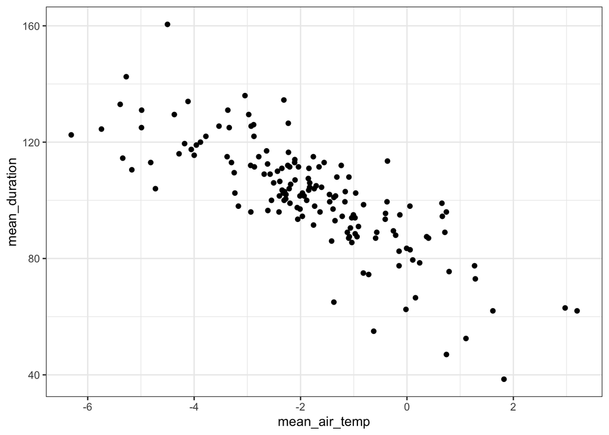

```r
ggplot(icecover_temp) +
   geom_point(aes(x = mean_air_temp, y = mean_duration), color = "black") +
  theme_bw()
```

```r
cor_test(
  data = icecover_temp,
  vars = c(mean_air_temp, mean_duration),
  alternative = "two.sided",
  method = "spearman"
)
```

```
## # A tibble: 1 × 6
##   var1          var2            cor statistic       p method
##   <chr>         <chr>         <dbl>     <dbl>   <dbl> <chr>
## 1 mean_air_temp mean_duration -0.83  1068645. 3.7e-39 Spearman
```

the correlation is negitive. The cor efficent is -0.83

Develop a simple linear model to then predict the mean ice duration when mean winter temperatures are -2 degrees, 0 degrees, and 2 degrees

```r
slr_model <- lm(mean_duration ~ mean_air_temp, data = icecover_temp)
summary(slr_model)
```

```
##
## Call:
## lm(formula = mean_duration ~ mean_air_temp, data = icecover_temp)
##
## Residuals:
##     Min      1Q  Median      3Q     Max
## -35.749  -5.303  -0.122   6.214  35.242
##
## Coefficients:
##               Estimate Std. Error t value Pr(>|t|)
## (Intercept)     85.186      1.363   62.50   <2e-16 ***
## mean_air_temp   -8.903      0.552  -16.13   <2e-16 ***
## ---
## Signif. codes:  0 '***' 0.001 '**' 0.01 '*' 0.05 '.' 0.1 ' ' 1
##
## Residual standard error: 11.43 on 150 degrees of freedom
## Multiple R-squared:  0.6343, Adjusted R-squared:  0.6319
## F-statistic: 260.2 on 1 and 150 DF,  p-value: < 2.2e-16
```

```r
icecover_temp_pp <- tibble(mean_air_temp = c(-2, 0, 2))

predict(slr_model, newdata = icecover_temp_pp)
```

```
##         1         2         3
## 102.99111  85.18557  67.38003
```

Plot the mean air temperature against the mean ice cover duration. Include our simple linear regression (i.e., the line of best fit) in the plot

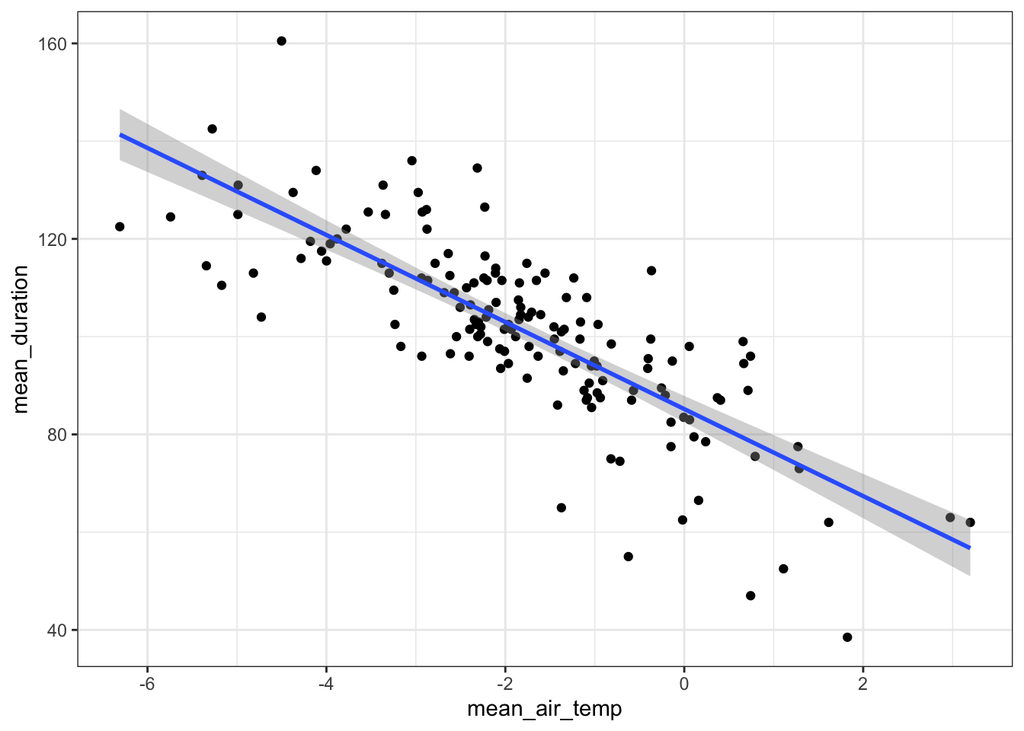

```r
ggplot(icecover_temp, (aes(x = mean_air_temp, y = mean_duration))) +
   geom_point(color = "black") +
   geom_smooth(method = "lm" , se = TRUE) +
  theme_bw()
```

slope = -8.903 intercept = 85.186 residual standard error = 11.43

## Module 5 Multiple Linear Regression

Multiple linear regression is the most common form of linear regression analysis. As a predictive analysis, multiple linear regression is used to explain the relationship between one continuous dependent variable (or, the response variable) and two or more independent variables (or, the predictor variables). The independent variables can be continuous OR categorical. Unlike a simple linear regression, where we describe the relationship between X and Y (two dimensional) and can simply plot them against each other, we are now working with multiple X’s and Y - which is three-dimensional.

We are interested in developing a multiple linear regression model to predict mean annual stream flow across the Eastern US. For every state, we have a handful of watershed and site characteristic data associated with USGS stream gauging stations.

```r
data_files <- list.files('data/usgs_gages', full.names = TRUE, pattern = "*.csv")
```

Read in each of the data sets associated with the assignment and combine them into a single data set

```r
combine_usgs <- map_dfr(data_files, read_csv)
```

Using our combined data set, plot mean annual stream flow against each variable to identify variables that seem to have a linear relationship with stream flow.

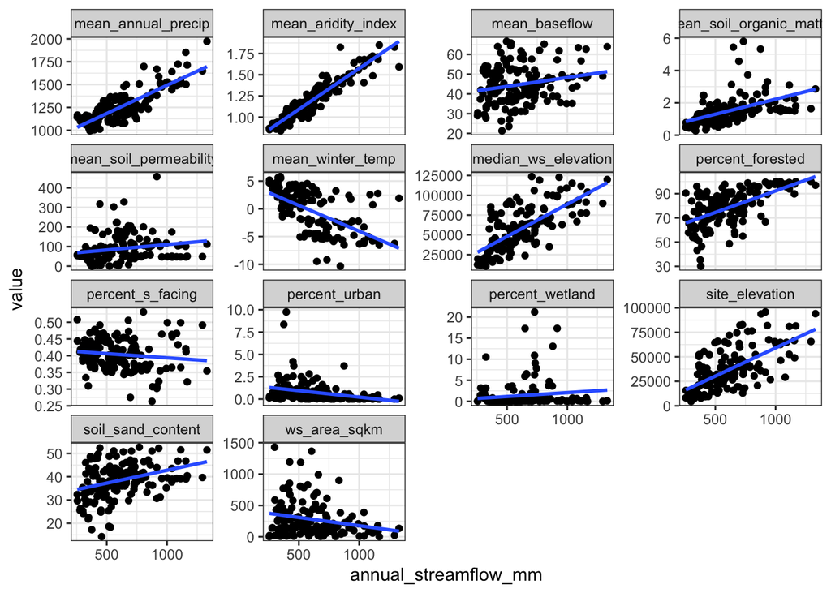

```r
data(combine_usgs)
combine_usgs_long <- combine_usgs %>%
  select(-c(site_name, state)) %>%
   pivot_longer(cols = -annual_streamflow_mm)

ggplot(data = combine_usgs_long, aes(x = annual_streamflow_mm, y = value)) +
  geom_point(color = "black") +
  geom_smooth(method = "lm", se = FALSE) +
  facet_wrap(~name, scales = "free_y") +
  theme_bw()
```

```r
mlr_model_usgs <- lm(sqrt(annual_streamflow_mm) ~ median_ws_elevation + mean_aridity_index + mean_winter_temp, data = combine_usgs)

summary(mlr_model_usgs)
```

```
##
## Call:
## lm(formula = sqrt(annual_streamflow_mm) ~ median_ws_elevation +
##     mean_aridity_index + mean_winter_temp, data = combine_usgs)
##
## Residuals:
##     Min      1Q  Median      3Q     Max
## -5.0399 -0.7844  0.0991  0.7073  3.3626
##
## Coefficients:
##                      Estimate Std. Error t value Pr(>|t|)
## (Intercept)         2.760e+00  7.009e-01   3.938 0.000126 ***
## median_ws_elevation 3.751e-05  4.678e-06   8.019 2.98e-13 ***
## mean_aridity_index  1.617e+01  6.564e-01  24.636  < 2e-16 ***
## mean_winter_temp    5.504e-02  3.719e-02   1.480 0.140994
## ---
## Signif. codes:  0 '***' 0.001 '**' 0.01 '*' 0.05 '.' 0.1 ' ' 1
##
## Residual standard error: 1.291 on 148 degrees of freedom
## Multiple R-squared:  0.9235, Adjusted R-squared:  0.922
## F-statistic: 595.9 on 3 and 148 DF,  p-value: < 2.2e-16
```

Check to see if your model meets the model assumptions required for MLR.

```r
combine_usgs %>%
  select(median_ws_elevation, mean_aridity_index, mean_winter_temp) %>%
  cor()
```

```
##                     median_ws_elevation mean_aridity_index mean_winter_temp
## median_ws_elevation           1.0000000          0.5847183       -0.4055794
## mean_aridity_index            0.5847183          1.0000000       -0.6611533
## mean_winter_temp             -0.4055794         -0.6611533        1.0000000
```

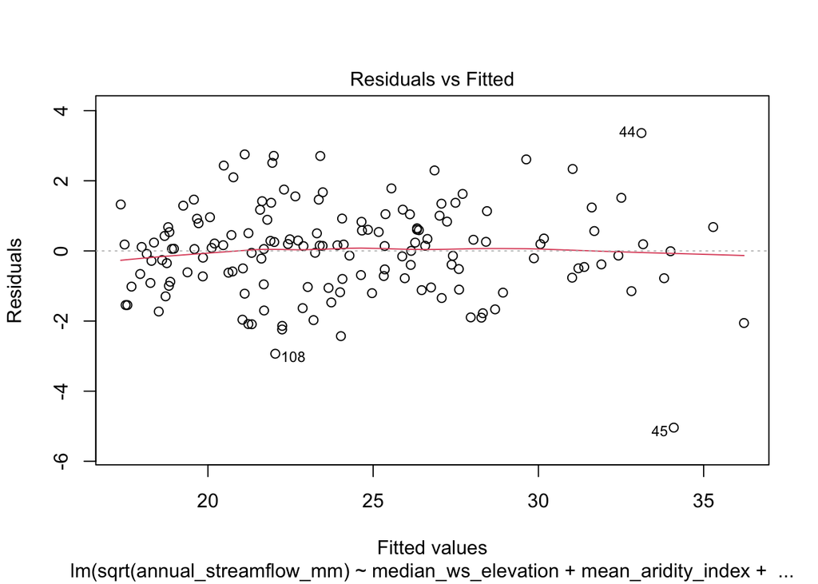

```r
plot(mlr_model_usgs, which = 1)
```

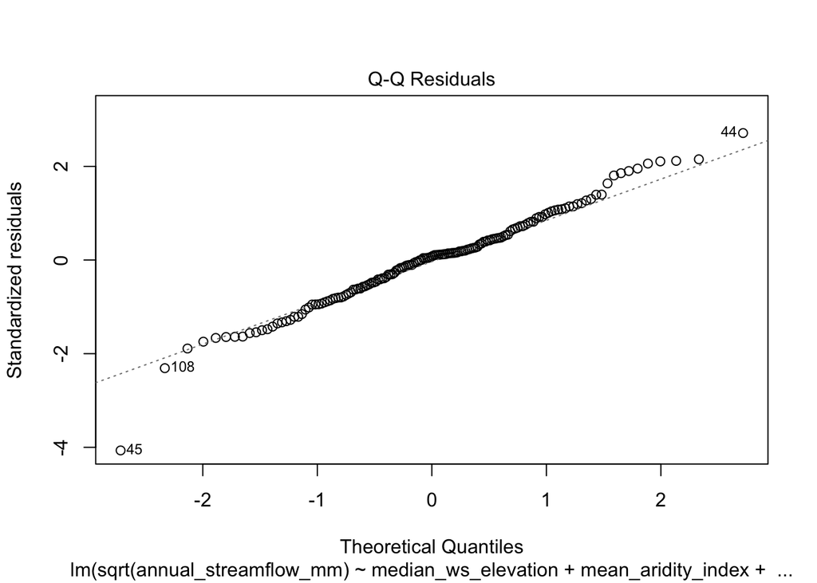

```r
plot(mlr_model_usgs, which = 2)
```

minipulating the predicted data, the plot looks like it fits assumptions except for the two outlires in the top and bottom (44 + 45) but the trend looks okay. The correlation is not above 0.7/-0.7 which makes this model good.

The Q-Q residuals plot looks like it meets assumptions.

Use your model to predict mean annual stream flow for two new sets of predictor data.

```r
mlr_model_usgs <- lm(sqrt(annual_streamflow_mm) ~ mean_aridity_index + mean_winter_temp, data = combine_usgs)

summary(mlr_model_usgs)
```

```
##
## Call:
## lm(formula = sqrt(annual_streamflow_mm) ~ mean_aridity_index +
##     mean_winter_temp, data = combine_usgs)
##
## Residuals:
##     Min      1Q  Median      3Q     Max
## -6.3847 -0.8672 -0.0110  0.8099  4.7870
##
## Coefficients:
##                    Estimate Std. Error t value Pr(>|t|)
## (Intercept)         1.98123    0.82852   2.391    0.018 *
## mean_aridity_index 18.60056    0.69503  26.762   <2e-16 ***
## mean_winter_temp    0.04573    0.04437   1.031    0.304
## ---
## Signif. codes:  0 '***' 0.001 '**' 0.01 '*' 0.05 '.' 0.1 ' ' 1
##
## Residual standard error: 1.541 on 149 degrees of freedom
## Multiple R-squared:  0.8903, Adjusted R-squared:  0.8888
## F-statistic: 604.8 on 2 and 149 DF,  p-value: < 2.2e-16
```

```r
reg_usgs <- tibble(annual_streamflow_mm = c(150, 180, 220, 200, 250, 280, 300, 350, 320, 400),
                   mean_aridity_index = c(120, 150, 180, 160, 210, 240, 260, 300, 280, 350),
                   mean_winter_temp = c(50, 60, 70, 65, 80, 90, 85, 95, 92, 100))

new_usgs <- data.frame(mean_aridity_index = c(250, 310),
                       mean_winter_temp =  c(88, 98))


predict(mlr_model_usgs, newdata = new_usgs)
```

```
##        1        2
## 4656.147 5772.638
```

## Module 6 Power